Ir al contenido

Ficha actualizada el 12 nov 2026

Ficha del establecimiento · RBD 9444

# Escuela Especial Los Cedros Del Líbano

San MiguelEscuela EspecialJornada escolar completa

Romina Silvana Tasso Ramirez

Dirección del establecimiento

🎒Matrícula

178

+5 respecto de 2025

📅Asistencia promedio

70,6 %

12,2 puntos bajo el promedio del SLEP

📇Estudiantes prioritarios

48,8 %

Concentración declarada (marzo)

¿Primera vez leyendo una ficha?Empieza por la ficha en cifras[Guía para leer los datos (se abre en otra pestaña)](https://datos.slepsantarosa.workers.dev/guia.html)

## La ficha en cifras

Cada cifra enlaza a su sección, donde está explicada y comparada con el SLEP.

📇Estudiantes prioritarios48,8 %Concentración declarada (marzo)Ver sección: Estudiantes prioritarios →

🎒Matrícula178+5 respecto de 2025Ver sección: Matrícula →

📅Asistencia promedio70,6 %12,2 puntos bajo el promedio del SLEPVer sección: Asistencia promedio →

📗Aprobación49,7 %Año escolar 2025Ver sección: Aprobación →

👥Funcionarios5222 docentes y 30 asistentes de la educaciónVer sección: Funcionarios →

📈Docentes en tramo avanzado o superior36 %8 de 22 docentesVer sección: Docentes en tramo avanzado o superior →

⭐SNED 2026-2027SeleccionadoÍndice de 94,7 sobre 100Ver sección: SNED 2026-2027 →

🛡️Denuncias registradas1Última en 2025Ver sección: Denuncias registradas →

🚨Hechos delictuales registrados1Último en 17 ene 2025Ver sección: Hechos delictuales registrados →

🗺️Niños y jóvenes en el barrio6.283De 0 a 17 años, a 800 m a la redondaVer sección: Niños y jóvenes en el barrio →

📍Estudiantes de la misma comuna37 %Viven en San Miguel, la comuna del establecimientoVer sección: Estudiantes de la misma comuna →

Capítulo

¿Qué establecimiento es y qué ofrece?

## 🏫El establecimiento

- 📇Identificación y contacto
- 🎭Vida escolar y participación

El establecimiento · Identificación y contactoDatos al 16 oct 2026

### 📇Identificación y contacto

¿Qué establecimiento es y cómo contactarlo?

Escuela Especial en funcionamiento en San Miguel, imparte educación especial y atiende a 178 estudiantes.

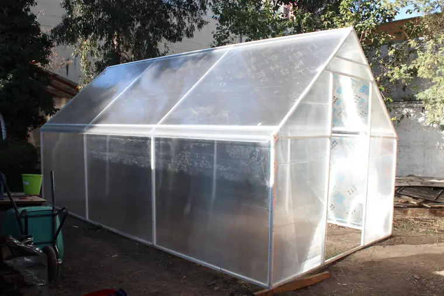

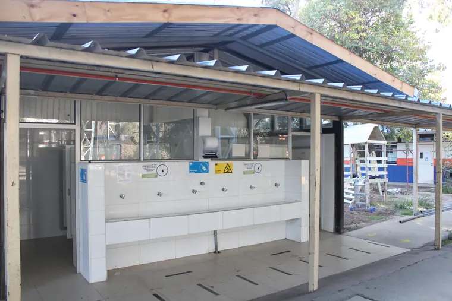

[figure not shown]

📷Fotografías del establecimiento

Concentración de estudiantes prioritarios

48,8 %

Estudiantes cuya situación socioeconómica puede afectar su rendimiento, según el Ministerio de Educación.

Cursos en funcionamiento

15

En educación especial

Programas y convenios

1

Jornada Escolar Completa

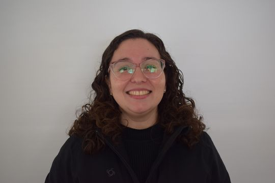

👤Dirección del establecimiento

Romina Silvana Tasso Ramirez

✉️escuelacedrosdellibano@slepsantarosa.cl

📱Celular: +56 9 7648 6177

☎️Teléfono del establecimiento: 43144696

🤝Asesoría técnica del SLEP: Rubén Cortez Gallardo · ruben.cortez@slepsantarosa.gob.cl

📍Dónde queda

Ricardo Morales 3370, San Miguel.

[interactive chart not shown]

Fuente: Coordenadas del directorio consolidado · [Abrir en Google Maps](https://www.google.com/maps/search/?api=1&query=-33.486294,-70.65289)

#### Identificación

**RBD**

9444-7

**Tipo de establecimiento**

Escuela Especial

**Dependencia**

Servicio Local de Educación Pública Santa Rosa

**Estado**

Funcionando

**Comuna**

San Miguel

#### Cómo contactarlo

**Dirección**

Ricardo Morales 3370

**Teléfono**

43144696

**Correo**

escuelacedrosdellibano@slepsantarosa.cl

#### Equipo y apoyo técnico

**Dirección**

Romina Silvana Tasso Ramirez

**Unidad Técnico Pedagógica**

utp.escuelacedrosdellibano@slepsantarosa.cl

**Inspectoría**

inspectoria.escuelacedrosdellibano@slepsantarosa.cl

**Asesoría técnica del SLEP**

Rubén Cortez Gallardo

**Correo de la asesoría**

ruben.cortez@slepsantarosa.gob.cl

#### Programas y convenios vigentes

Jornada Escolar CompletaSin convenio PIESin PACE

#### Apoyos profesionales al aprendizaje

PsicologíaOtro: Educadores diferenciales, fonoaudiólgo,kinesiólogoReforzamientoPsicopedagogíaOrientaciónOrientación vocacionalProfesor o profesora de educación especialTrabajo socialFonoaudiología

#### Necesidades educativas que atiende

Tipos de necesidades educativas especiales que el establecimiento declara atender.

Discapacidad intelectualDiscapacidad motora

#### Infraestructura declarada

Biblioteca (CRA)Sala de usos múltiplesComputación con internetCancha deportivaGimnasio techadoAccesibilidad para NEEOtro: Gimnasios kinésicos, clínica fonoaudiológicaLaboratorio de cienciasSala audiovisual

#### Documentos públicos

[Proyecto Educativo Institucional (PEI)](https://wwwfs.mineduc.cl/Archivos/infoescuelas/documentos/9444/ProyectoEducativo9444.pdf)[Reglamento de convivencia](https://wwwfs.mineduc.cl/Archivos/infoescuelas/documentos/9444/ReglamentodeConvivencia9444.pdf)[Reglamento de evaluación](https://wwwfs.mineduc.cl/Archivos/infoescuelas/documentos/9444/ReglamentoDeEvaluacion9444.pdf)

**¿Cómo se lee este dato?**

**Qué es**

La identificación oficial del establecimiento y las vías para comunicarse con él.

**De dónde sale**

Del directorio consolidado que el equipo actualiza cada mes con el registro oficial del Ministerio de Educación y los datos del propio Servicio Local.

**Cómo leerlo**

El **RBD** es el número con que el Ministerio identifica a cada establecimiento: sirve para buscarlo en cualquier sistema público. **Dependencia** indica quién lo administra; desde el traspaso, es el Servicio Local de Educación Pública.

**Referencia**

La **concentración de estudiantes prioritarios** es el porcentaje de estudiantes cuya situación socioeconómica puede dificultar su trayectoria escolar; el Ministerio la usa para asignar la subvención escolar preferencial.

**Lo que no dice**

Que un establecimiento tenga más programas no significa mejores resultados: son convenios a los que se postula según su proyecto y su matrícula.

**Para saber más**

[Guía para leer los datos: Cómo leer una ficha (se abre en otra pestaña)](https://datos.slepsantarosa.workers.dev/guia.html#empezar)

El establecimiento · Vida escolar y participación

### 🎭Vida escolar y participación

¿Quiénes participan en la comunidad educativa?

El establecimiento tiene centro de padres y apoderados, con personalidad jurídica vigente y cuenta con centro de estudiantes.

Centro de padres

Constituido

Personalidad jurídica: vigente

Centro de estudiantes

Constituido

Lo integran estudiantes del establecimiento

Consejo escolar

Con representante del sostenedor

Osman Yeomans Jiménez

#### Centro de padres y apoderados

**Personalidad jurídica**

Vigente

**Certificado de directorio vigente**

DPJ_ESCUELA CEDROS DEL LÍBANO.pdf

**Última elección del directorio**

**Próxima elección**

Para contactarlo, escribe al establecimiento: sus datos están en «Identificación y contacto».

#### Centro de estudiantes

El establecimiento tiene centro de estudiantes constituido. Lo integran estudiantes del propio establecimiento.

#### Consejo escolar

**Representante del sostenedor**

Osman Yeomans Jiménez

**Acompañamiento del SLEP**

Solange Oñate Castillo

**¿Cómo se lee este dato?**

**Qué es**

Las tres instancias de participación que la ley exige a cada establecimiento: el **consejo escolar** (donde se encuentran dirección, docentes, asistentes, apoderados y estudiantes), el **centro de padres** y el **centro de estudiantes**.

**De dónde sale**

Del registro que mantiene el Servicio Local con los establecimientos, actualizado cuando hay elecciones o cambios de directiva.

**Cómo leerlo**

La **personalidad jurídica** permite al centro de padres administrar recursos propios. Un centro sin directorio vigente no puede firmar convenios ni recibir aportes.

**Lo que no dice**

Que una instancia figure constituida no dice cuán activa es: el registro solo guarda su estado formal.

Capítulo

¿A quiénes educa y cómo avanzan durante el año?

## 🧒Estudiantes

- 🎒Matrícula
- 📅Asistencia
- 🪑Ocupación de cursos
- 🤝Programa de Integración Escolar (PIE)
- 🚶Retiros y traslados

Estudiantes · MatrículaDatos de septiembre de 2026

### 🎒Matrícula

¿Cuántos estudiantes tiene y cómo ha cambiado?

En septiembre de 2026 estudian 178 estudiantes en el establecimiento, 5 más que en 2025. El 45,5 % son mujeres y el 19,1 % tiene nacionalidad extranjera.

Estudiantes matriculados

178

+5 estudiantes respecto de 2025 (+2,9 %)

82

SLEP 300178

915Rango de los establecimientos del SLEP

Estudiantes por curso

11,9

15 cursos en funcionamiento

10,5

SLEP 23,811,9

39,5Rango de los establecimientos del SLEP

Estudiantes mujeres

45,5 %

81 de 178 estudiantes

0,0 %

SLEP 46,5 %45,5 %

100,0 %Rango de los establecimientos del SLEP

Estudiantes extranjeros

19,1 %

34 de 178 estudiantes

6,5 %

SLEP 29,8 %19,1 %

77,6 %Rango de los establecimientos del SLEP

La matrícula creció 2,9 % en el último año

Estudiantes matriculados en septiembre de cada año, según el registro mensual del SIGE.

[interactive chart not shown]

Fuente: SIGE, MINEDUC.

#### Género, nacionalidad y origen

Cómo se reparten los 178 estudiantes de septiembre de 2026, según lo que el establecimiento registra de cada uno en el SIGE. Los porcentajes son sobre el total de estudiantes.

#### Por género

- **Mujeres**45,5 % · 81 estudiantes
- **Hombres**54,5 % · 97 estudiantes

#### Por nacionalidad

- **Chilena**80,9 % · 144 estudiantes
- **Extranjera**19,1 % · 34 estudiantes

#### País de origen distinto de Chile

- Venezuela2,8 %5
- Otros5,1 %9

Los grupos de menos de 5 estudiantes se suman en «Otros» para no identificar a nadie. Por esa regla no se muestra el desglose por pueblo originario: no quedan al menos dos grupos que se puedan publicar. País de origen: la tarjeta muestra los países declarados en el registro, sin contar Chile (14 estudiantes). Es un dato distinto de la nacionalidad (34 estudiantes de nacionalidad extranjera) y no siempre coincide con ella: muestra lo que el establecimiento registró, no el total de estudiantes de cada país.

**¿Cómo se lee este dato?**

**Qué es**

La cantidad de estudiantes inscritos en el establecimiento en el mes de corte, y cómo se reparte ese total por género, nacionalidad, país de origen y pueblo originario.

**De dónde sale**

Del Sistema de Información General de Estudiantes (SIGE), que cada establecimiento actualiza mes a mes. El género, la nacionalidad, el país de origen y el pueblo originario son los que el establecimiento registra al matricular a cada estudiante.

**Cómo leerlo**

Mira la tendencia de varios años antes que un mes aislado: la matrícula se mueve todo el año por traslados, retiros y nuevas incorporaciones. En el desglose, los grupos de menos de 5 estudiantes se suman en «Otros» para no identificar a nadie; si aun así no quedan al menos dos grupos, ese desglose no se muestra.

**Lo que no dice**

Que un establecimiento tenga más estudiantes no significa que enseñe mejor: el tamaño depende de la infraestructura, de los cupos declarados y del barrio. En el desglose, una diferencia chica entre dos grupos puede ser un solo estudiante: mira también el número, no solo el porcentaje. La nacionalidad y el país de origen son dos datos distintos del registro y no siempre calzan: un estudiante de nacionalidad extranjera puede figurar con Chile como país de origen. Por eso sus cifras no tienen por qué coincidir.

**Para saber más**

[Guía para leer los datos: Matrícula (se abre en otra pestaña)](https://datos.slepsantarosa.workers.dev/guia.html#matricula)

**Ver la matrícula curso por curso (15 cursos)**

Matrícula por curso

| Curso | Estudiantes | % del total |
| --- | --- | --- |
| 1° Básico A | 12 | 6,7 % |
| 2° Básico A | 6 | 3,4 % |
| 3° Básico A | 8 | 4,5 % |
| 4° Básico A | 15 | 8,4 % |
| 5° Básico A | 12 | 6,7 % |
| 6° Básico A | 8 | 4,5 % |
| 7° Básico A | 14 | 7,9 % |
| 8° Básico A | 13 | 7,3 % |
| Nivel de Transición 1 A | 9 | 5,1 % |
| Nivel de Transición 2 A | 15 | 8,4 % |
| Laboral 1 A | 14 | 7,9 % |
| Laboral 1 B | 14 | 7,9 % |
| Laboral 1 C | 14 | 7,9 % |
| Laboral 1 E | 10 | 5,6 % |
| Laboral 1 G | 14 | 7,9 % |

Estudiantes · AsistenciaDatos de septiembre de 2026

### 📅Asistencia

¿Cuántos estudiantes van a clases todos los días?

De marzo a septiembre de 2026, los estudiantes asistieron en promedio 70,6 % de los días con clases: 12,2 puntos bajo el promedio del SLEP (82,8 %). Entre las mujeres la asistencia fue de 65,9 % y entre los hombres, de 74,5 %.

Asistencia promedio del año

70,6 %

−1,3 puntos respecto de 2025

49,4 %

SLEP 82,8 %70,6 %

90,4 %Rango de los establecimientos del SLEP

Asistencia de septiembre

72,5 %

178 estudiantes en 15 cursos

Curso con menor asistencia

55,5 %

2° Básico A · 15,1 puntos bajo el promedio del establecimiento

Ningún mes de 2026 alcanza el 85 %

Asistencia promedio del establecimiento en cada mes de 2026, ponderada por la matrícula de cada curso.

[interactive chart not shown]

Fuente: SIGE, MINEDUC.

#### Asistencia por género, nacionalidad y origen

Asistencia promedio de marzo a septiembre de 2026 de cada grupo, calculada igual que la del establecimiento: ponderada por la cantidad de estudiantes del grupo en cada curso. La raya marca el promedio del establecimiento (70,6 %). Bajo el nombre de cada grupo va su cantidad de estudiantes en septiembre.

#### Por género

- Mujeres81 estudiantes65,9 %
- Hombres97 estudiantes74,5 %

Promedio del establecimiento: **70,6 %**

#### Por nacionalidad

- Chilena144 estudiantes71,5 %
- Extranjera34 estudiantes66,8 %

Promedio del establecimiento: **70,6 %**

La asistencia de un grupo se publica solo si tuvo 10 o más estudiantes en todos los meses del período, para no identificar a nadie; los grupos más chicos se suman en «Otros». Por esa regla no se muestra la asistencia por país de origen ni por pueblo originario.

**¿Cómo se lee este dato?**

**Qué es**

La proporción entre los días que un estudiante va a clases y los días que hubo clases. La asistencia de un curso, de un grupo de estudiantes o de un establecimiento es el promedio de esos porcentajes.

**De dónde sale**

El establecimiento registra la asistencia todos los días y la declara cada mes en el Sistema de Información General de Estudiantes (SIGE). Esa misma asistencia es la base de la subvención.

**Cómo leerlo**

Compara cada mes con el mismo mes del año anterior: marzo y diciembre se leen distinto por el ingreso escalonado y el cierre del año. En el desglose por género, nacionalidad y origen, la asistencia de un grupo se publica solo si tuvo 10 o más estudiantes durante todo el período, para no identificar a nadie.

**Referencia**

El Decreto 67 de 2018 exige al menos 85 % de asistencia en el año para ser promovido, con excepciones que autoriza la dirección. El Centro de Estudios del Ministerio usa cuatro categorías: destacada (97 % o más), normal (90 a 97 %), inasistencia reiterada (85 a 90 %) e inasistencia grave (85 % o menos).

**Lo que no dice**

Cuántos estudiantes faltan mucho. Un promedio alto puede esconder a varios estudiantes bajo el 85 %: para saberlo hay que mirar caso a caso, no el promedio. Tampoco que un grupo falte más que otro por una diferencia de uno o dos puntos: en grupos de menos de 20 estudiantes el promedio cambia mucho con un solo caso, y el dato no dice por qué falta cada estudiante.

**Para saber más**

[Guía para leer los datos: Asistencia (se abre en otra pestaña)](https://datos.slepsantarosa.workers.dev/guia.html#asistencia)

**Ver la asistencia curso por curso (15 cursos)**

Asistencia por curso, marzo a septiembre de 2026

| Curso | Estudiantes | Asistencia del año | Situación |
| --- | --- | --- | --- |
| 1° Básico A | 12 | 60,6 % | Bajo el umbral |
| 2° Básico A | 6 | 55,5 % | Bajo el umbral |
| 3° Básico A | 7 | 81,1 % | Bajo el umbral |
| 4° Básico A | 15 | 57,0 % | Bajo el umbral |
| 5° Básico A | 11 | 66,4 % | Bajo el umbral |
| 6° Básico A | 8 | 74,0 % | Bajo el umbral |
| 7° Básico A | 14 | 78,4 % | Bajo el umbral |
| 8° Básico A | 13 | 70,3 % | Bajo el umbral |
| Nivel de Transición 1 A | 9 | 69,5 % | Bajo el umbral |
| Nivel de Transición 2 A | 15 | 68,0 % | Bajo el umbral |
| Laboral 1 A | 13 | 72,8 % | Bajo el umbral |
| Laboral 1 B | 14 | 66,4 % | Bajo el umbral |
| Laboral 1 C | 14 | 71,0 % | Bajo el umbral |
| Laboral 1 E | 10 | 94,4 % | Sobre el umbral |
| Laboral 1 G | 14 | 76,8 % | Bajo el umbral |

Estudiantes · Ocupación de cursos

### 🪑Ocupación de cursos

¿Cuántos cupos están ocupados en cada curso?

**Sin datos para este establecimiento**Este establecimiento no tiene cupos declarados en el Sistema de Admisión Escolar (SAE) para este período, así que no se puede calcular cuántos de sus cupos están ocupados.

Estudiantes · PIEDatos de abril de 2026

### 🤝Programa de Integración Escolar (PIE)

¿Cuántos estudiantes reciben apoyos del Programa de Integración Escolar?

3 estudiantes están inscritos en el Programa de Integración Escolar, dentro de una matrícula de 178 estudiantes que en su totalidad cursa educación especial.

Este es un establecimiento de educación especial: toda su matrícula recibe apoyos especializados. La nómina del Programa de Integración Escolar cuenta solo a los estudiantes incorporados formalmente al programa, por eso su porcentaje no es comparable con el de una escuela o liceo regular.

Estudiantes en el PIE

3

de 178 estudiantes matriculados en septiembre de 2026

3

SLEP 533

140Rango de los establecimientos del SLEP

Porcentaje de la matrícula

1,7 %

−17,1 puntos respecto del promedio del SLEP (18,8 %)

1,7 %

SLEP 18,8 %1,7 %

34,2 %Rango de los establecimientos del SLEP

Con 3 estudiantes en el programa no se muestran el diagnóstico, el tipo de necesidad ni ningún otro desglose: con menos de 5 estudiantes, cualquiera de ellos permitiría identificar a cada uno.

**¿Cómo se lee este dato?**

**Qué es**

El Programa de Integración Escolar (PIE) entrega apoyos adicionales —profesionales de apoyo, horas de trabajo conjunto con los docentes y materiales— a los estudiantes que tienen una necesidad educativa especial (NEE) diagnosticada, dentro de la misma sala de clases.

**De dónde sale**

El detalle por estudiante sale de la nómina PIE del SIGE (abril de 2026) y la serie por año, del catastro del Área de Inclusión Educativa del SLEP. Son dos registros distintos, con fechas distintas: sus totales no calzan exactamente.

**Cómo leerlo**

Una necesidad «permanente» acompaña a la persona durante toda su vida —por ejemplo una discapacidad intelectual, sensorial o motora— y da derecho a apoyos en toda la trayectoria escolar. Una necesidad «transitoria» se presenta en un período de la escolaridad y se espera que se supere con apoyo, como las dificultades del aprendizaje o del lenguaje. En la mayoría de los establecimientos las transitorias son las más numerosas.

**Referencia**

En el SLEP Santa Rosa el promedio es 18,8 % de la matrícula. El programa se rige por el Decreto 170 del Ministerio de Educación, que define qué diagnósticos puede atender y qué apoyos financia.

**Lo que no dice**

Un porcentaje alto de estudiantes en el PIE no es un mal resultado: habla de cuántos estudiantes tienen apoyos reconocidos y financiados, no de cómo enseña el establecimiento. Tampoco dice cuántos estudiantes necesitan apoyo, porque solo cuenta a quienes ya tienen un diagnóstico vigente y entraron al programa. Por lo mismo, las diferencias por género, nivel o nacionalidad muestran a quiénes se ha diagnosticado, no quiénes necesitan más apoyo. Los grupos de menos de 5 estudiantes se suman en «Otros» para no identificar a nadie, y con menos de 5 estudiantes en el programa no se muestra ningún desglose.

Estudiantes · Retiros y trasladosDatos de junio de 2026

### 🚶Retiros y traslados

¿Cuántos estudiantes se fueron durante el año y por qué?

En 2026 se registraron 1 retiro: 0,6 % de la matrícula, 13,2 puntos bajo el promedio del SLEP (13,7 %).

Retiros registrados en 2026

1

−13 respecto del mismo período de 2025 (14 retiros)

1

SLEP 391

155Rango de los establecimientos del SLEP

Porcentaje de la matrícula

0,6 %

−13,2 puntos respecto del promedio del SLEP (13,7 %)

0,6 %

SLEP 13,7 %0,6 %

103,3 %Rango de los establecimientos del SLEP

Dejaron el establecimiento

1estudiante

con al menos un retiro registrado en el año

Junio concentró la mayor cantidad de retiros: 1 de 1

Retiros registrados cada mes de 2026, desde marzo hasta junio.

[interactive chart not shown]

Fuente: Registro de retiros y traslados del SIGE, MINEDUC.

Con 1 estudiante que dejó el establecimiento no se muestran desgloses por género, nacionalidad, curso ni destino: con menos de 5 estudiantes, cualquiera de ellos permitiría identificar a cada uno.

**¿Cómo se lee este dato?**

**Qué es**

Un retiro es el registro que hace el establecimiento en el SIGE cuando un estudiante deja su curso durante el año escolar. No todos los retiros son iguales: la mayoría son traslados, es decir, el estudiante se matricula en otro establecimiento y sigue estudiando.

**De dónde sale**

Del registro de retiros y traslados del SIGE, cruzado con la matrícula vigente para saber dónde quedó cada estudiante. El corte de estos datos es junio de 2026.

**Cómo leerlo**

Distingue el «traslado a otro establecimiento» —el estudiante sigue en el sistema escolar, dentro o fuera del SLEP— del «retiro sin matrícula posterior», que es el que conviene mirar de cerca, porque puede anticipar una desvinculación del sistema. Los meses de marzo y diciembre concentran movimientos administrativos —regularizaciones de inicio de año y cierres de curso—, así que un alza en esos meses no significa lo mismo que un alza en mitad del año. Los desgloses por género, nacionalidad, nivel y destino cuentan estudiantes, no movimientos, y dejan fuera los cambios de curso internos.

**Referencia**

En el SLEP Santa Rosa los retiros equivalen en promedio a 13,7 % de la matrícula en lo que va de 2026. La comparación se hace con el mismo corte para todos los establecimientos.

**Lo que no dice**

El retiro no es lo mismo que la deserción: solo la matrícula del año siguiente confirma si un estudiante dejó de estudiar. Y como el año todavía no termina, la cifra seguirá subiendo hasta diciembre: no se puede comparar con el total de un año cerrado. Los desgloses tampoco dicen por qué se fue cada estudiante, y con tan pocos casos una diferencia entre grupos puede ser casualidad. Los grupos de menos de 5 estudiantes se suman en «Otros» para no identificar a nadie.

**Para saber más**

[Guía para leer los datos: Matrícula (se abre en otra pestaña)](https://datos.slepsantarosa.workers.dev/guia.html#matricula)

**Ver el detalle mes a mes**

Retiros de 2026 por mes

| Mes del retiro | Retiros |
| --- | --- |
| Marzo | 0 |
| Abril | 0 |
| Mayo | 0 |
| Junio | 1 |
| Total | 1 |

Capítulo

¿Qué están aprendiendo sus estudiantes?

## 📚Aprendizajes

- 📗Rendimiento
- 📊SIMCE
- 💛Desarrollo personal y social
- 🧭Diagnóstico Integral de Aprendizajes (DIA)

Aprendizajes · RendimientoDatos de año escolar 2025

### 📗Rendimiento

¿Cuántos estudiantes aprobaron el año?

En 2025, 49,7 % de los estudiantes que terminaron el año fue promovido de curso, 46,8 puntos bajo el promedio del SLEP.

Estudiantes promovidos

49,7 %

−39,6 puntos respecto de 2024

49,7 %

SLEP 96,5 %49,7 %

100,0 %Rango de los establecimientos del SLEP

Nota promedio del establecimiento

5,9

Promedio general de 85 estudiantes con nota final

5,4

SLEP 5,95,9

6,3Rango de los establecimientos del SLEP

Reprobados por inasistencia

30

De 87 estudiantes reprobados en 2025

La aprobación bajó 39,6 puntos respecto de 2024

Porcentaje de estudiantes promovidos sobre los que terminaron el año en el establecimiento (no incluye retirados ni trasladados).

Promedio del SLEP en 2025: 96,5 %

[interactive chart not shown]

Fuente: Actas de rendimiento, SIGE.

#### Aprobación y notas por género y nacionalidad

Resultados de 2025 de quienes terminaron el año, mirando una característica a la vez. La raya marca el valor de todo el establecimiento.

#### Aprobación por género

- Mujeres82 estudiantes51,2 %
- Hombres91 estudiantes48,4 %

Aprobación del establecimiento: **49,7 %**

#### Nota promedio por género

- Mujeres43 con nota final5,9
- Hombres42 con nota final5,8

Nota del establecimiento: **5,9**

#### Aprobación por nacionalidad

- Chilena142 estudiantes48,6 %
- Extranjera31 estudiantes54,8 %

Aprobación del establecimiento: **49,7 %**

#### Nota promedio por nacionalidad

- Chilena67 con nota final5,9
- Extranjera18 con nota final5,9

Nota del establecimiento: **5,9**

**¿Cómo se lee este dato?**

**Qué es**

El resultado del año escolar de cada estudiante: promovido al curso siguiente o reprobado.

**De dónde sale**

De las actas de rendimiento que el establecimiento entrega al Ministerio al cerrar el año, a través del SIGE.

**Cómo leerlo**

La aprobación se calcula sobre quienes **terminaron el año** en el establecimiento. Los estudiantes **retirados** o **trasladados** se cuentan aparte (sección Retiros y traslados), porque su resultado final lo registra otro establecimiento. La nota promedio es el promedio general de cada estudiante con nota final, no un promedio de cursos.

**Referencia**

Un estudiante puede reprobar por notas o por asistencia inferior al 85 % sin justificación aceptada por la dirección.

**Lo que no dice**

Una aprobación de 100 % no significa por sí sola que todos aprendieron lo esperado: para eso están los resultados del SIMCE y del DIA. Las diferencias por género, nacionalidad o curso tampoco explican su causa, y en grupos chicos un solo estudiante mueve varios puntos: por eso las tasas y los promedios solo se muestran para grupos de 10 o más estudiantes, y los más chicos se suman en «Otros» para no identificar a nadie.

**Para saber más**

[Guía para leer los datos: Rendimiento (se abre en otra pestaña)](https://datos.slepsantarosa.workers.dev/guia.html#rendimiento)

**Ver el detalle por curso**

Rendimiento por curso

| Curso | Evaluados | Aprobación | Nota promedio |
| --- | --- | --- | --- |
| Nivel de Transición 1 | 11 | 36,4 % | — |
| Nivel de Transición 2 | 12 | 66,7 % | — |
| 2° Básico | 11 | 36,4 % | 5,4 |
| 3° Básico | 12 | 58,3 % | 6,2 |
| 4° Básico | 15 | 60,0 % | 5,7 |
| 6° Básico | 12 | 91,7 % | 5,8 |
| 7° Básico | 10 | 70,0 % | 5,8 |
| 8° Básico | 13 | 46,2 % | 5,9 |
| Laboral 1 | 65 | 32,3 % | — |
| Otros cursos | 12 | 75,0 % | 6,3 |

Aprendizajes · SIMCE

### 📊SIMCE

¿Cómo les fue en las pruebas nacionales SIMCE?

**Sin datos para este establecimiento**Este establecimiento no registra resultados SIMCE en las bases del equipo. El SIMCE se aplica en 4° y 8° básico y en 2° medio; los establecimientos con pocos estudiantes evaluados no reciben resultados publicables.

Aprendizajes · Desarrollo personal y social

### 💛Desarrollo personal y social

¿Cómo se sienten los estudiantes en su establecimiento?

**Sin datos para este establecimiento**Este establecimiento no registra Indicadores de Desarrollo Personal y Social. Los calcula la Agencia de Calidad con los cuestionarios que acompañan al SIMCE, así que solo existen para los cursos que rinden esa prueba.

Aprendizajes · Diagnóstico Integral de Aprendizajes (DIA)

### 🧭Diagnóstico Integral de Aprendizajes (DIA)

¿Qué aprendizajes lograron durante el año según el DIA?

**Sin datos para este establecimiento**Este establecimiento no registra aplicaciones del Diagnóstico Integral de Aprendizajes (DIA) en las bases que procesa el equipo del SLEP. El DIA es de aplicación voluntaria: cada establecimiento decide si lo rinde, en qué áreas y en qué momentos del año.

Capítulo

¿Quiénes trabajan en el establecimiento?

## 👥Equipo

- 👥Funcionarios y dotación
- 📈Desarrollo profesional docente

Equipo · Funcionarios y dotaciónDatos de cierre de agosto de 2026

### 👥Funcionarios y dotación

¿Cuántas personas trabajan en el establecimiento?

En agosto de 2026 trabajan 52 personas en el establecimiento: 22 docentes y 30 asistentes de la educación, 3 personas más que en agosto de 2025.

Personas contratadas

52

+3 personas respecto de agosto de 2025

22

SLEP 5552

128Rango de los establecimientos del SLEP

Docentes

22

42 % del equipo · 15 de aula · 43,1 horas de contrato a la semana, en promedio

11

SLEP 3122

84Rango de los establecimientos del SLEP

Asistentes de la educación

30

58 % del equipo · 40,7 horas de contrato a la semana, en promedio

Estudiantes por docente

8,1

178 estudiantes matriculados en agosto de 2026 y 22 docentes

4,8

SLEP 9,68,1

15,7Rango de los establecimientos del SLEP

Docentes de aula: 15 de las 52 personas del equipo

Personas contratadas en agosto de 2026, según la función de su contrato principal. Cada persona cuenta una sola vez, aunque tenga más de un contrato. Las funciones con menos de 5 personas van juntas. «Otras funciones docentes»: coordinación y apoyo técnico; equipo directivo. «Otras funciones de asistentes»: administrativos; auxiliares de servicio; técnicos en párvulos.

DocentesAsistentes de la educación

- Docentes de aula29 % del equipo15
- Otras funciones docentes13 % del equipo7
- Profesionales de apoyo21 % del equipo11
- Asistentes de aula e inspectoría15 % del equipo8
- Otras funciones de asistentes21 % del equipo11

Fuente: Maestro de remuneraciones (planilla P02), SLEP Santa Rosa.

#### El equipo según género, tipo de contrato y horas semanales

#### Por género

- **Mujeres**85 % · 44 personas
- **Hombres**15 % · 8 personas

#### Por tipo de contrato

- **Titular o planta**65 % · 34 personas
- **Contrata**25 % · 13 personas
- **Código del Trabajo o reemplazo**10 % · 5 personas

#### Por horas de contrato a la semana

- **44 horas**77 % · 40 personas
- **Menos de 44 horas**23 % · 12 personas

Los grupos de menos de 5 personas no se publican por separado: se suman a otro grupo o el desglose no se muestra, para no identificar a nadie.

**¿Cómo se lee este dato?**

**Qué es**

La **dotación** es el conjunto de personas contratadas para trabajar en el establecimiento en un mes determinado. Se rige por dos estatutos: el **Estatuto Docente** (Ley N° 19.070) para los profesionales de la educación —docentes de aula, directivos y técnico-pedagógicos— y el **Estatuto de los Asistentes de la Educación** (Ley N° 21.109), vigente desde 2018, para quienes apoyan el proceso educativo sin hacer clases: profesionales, técnicos, administrativos y auxiliares. Se cuentan **personas**, no contratos: quien tiene dos contratos en el mismo establecimiento cuenta una vez, con la función y el tipo de contrato de su contrato principal y la suma de las horas de todos.

**De dónde sale**

De la planilla **P02**, el registro mensual de personal con que la Subdirección de Gestión de Personas del SLEP Santa Rosa procesa las remuneraciones de todos sus establecimientos. De esa planilla la ficha solo usa conteos agregados: **no muestra nombres, RUT ni remuneraciones** de ninguna persona, ni las horas o el tipo de contrato de un cargo en particular. El total del Visor Dotación y carrera docente del portal puede ser algo menor que el de esta ficha, porque ese visor informa aparte a quienes cubren un reemplazo.

**Cómo leerlo**

La barra bajo cada cifra muestra dónde queda el establecimiento dentro del rango de los establecimientos del SLEP. En las **funciones**, «Profesionales de apoyo» reúne a psicólogos, trabajadores sociales, fonoaudiólogos, terapeutas y personal de salud financiados por el Programa de Integración Escolar (PIE) y la Subvención Escolar Preferencial (SEP). En el **tipo de contrato**, titular o planta es el ingreso por concurso público; contrata cubre tareas transitorias; Código del Trabajo es la modalidad con que está contratada una parte de los asistentes de la educación; reemplazo cubre la ausencia temporal de otra persona. Las **horas de contrato** son las pactadas a la semana: 44 es la jornada completa. Mira la evolución mensual antes que un mes aislado: marzo y los meses con más reemplazos mueven la cifra.

**Referencia**

El Estatuto Docente distingue a los docentes **titulares**, que ingresan por concurso público, de los **contratados**, para tareas transitorias, y fija un máximo de 20 % de horas docentes a contrata. Ese límite se mide sobre toda la dotación docente del sostenedor —aquí, el Servicio Local—, no establecimiento por establecimiento: por eso la ficha no lo calcula.

**Lo que no dice**

Que un establecimiento tenga más funcionarios no significa que atienda mejor: la dotación se fija cada noviembre según la matrícula, los cursos y el tipo de educación que imparte. Para leerla hay que mirarla junto con la matrícula —por eso está la cifra de estudiantes por docente, que cuenta a todos los docentes y no es el tamaño de los cursos— y recordar que los establecimientos con Programa de Integración Escolar o educación especial necesitan más profesionales de apoyo por estudiante.

**Ver la dotación mes a mes en tabla (2026)**

Personas contratadas cada mes, por estatuto

| Mes | Docentes | Asistentes de la educación | Total |
| --- | --- | --- | --- |
| enero de 2026 | 24 | 24 | 48 |
| febrero de 2026 | 24 | 24 | 48 |
| marzo de 2026 | 24 | 24 | 48 |
| abril de 2026 | 23 | 27 | 50 |
| mayo de 2026 | 22 | 27 | 49 |
| junio de 2026 | 22 | 29 | 51 |
| julio de 2026 | 22 | 29 | 51 |
| agosto de 2026 | 22 | 30 | 52 |

Equipo · Desarrollo profesional docenteDatos de cierre de agosto de 2026

### 📈Desarrollo profesional docente

¿En qué tramo de la carrera docente están sus profesores?

En agosto de 2026, 8 de los 22 docentes del establecimiento están en tramo avanzado o superior de la Carrera Docente.

Docentes

22

Todos los del Estatuto Docente: de aula, directivos y técnico-pedagógicos

En tramo avanzado o superior

36 %

8 de 22 docentes, en Avanzado, Experto I o Experto II · sin cambio respecto de agosto de 2025

26,1 %

SLEP 50,8 %36,4 %

80,0 %Rango de los establecimientos del SLEP

Los docentes, según su tramo en la Carrera Docente

Docentes del establecimiento en cada tramo de la Carrera Docente en agosto de 2026, en el orden en que se avanza. Los tramos con menos de 5 docentes se muestran juntos.

- Acceso, Inicial o Temprano64 % de los docentes14
- Avanzado, Experto I o Experto II36 % de los docentes8

Fuente: Maestro de remuneraciones (planilla P02), SLEP Santa Rosa, con el tramo asignado por el CPEIP.

#### Cómo ha cambiado y cuánta experiencia tiene el equipo

#### En tramo avanzado o superior, año a año

- 20259 de 25 docentes36 %
- 20268 de 22 docentes36 %

#### Por años de servicio reconocidos

- **Menos de 14 años**45 % · 10 docentes
- **14 años o más**55 % · 12 docentes

Los grupos de menos de 5 docentes no se publican por separado: un tramo con pocos docentes se muestra junto a otro de su mismo grupo, para no identificar a nadie.

**¿Cómo se lee este dato?**

**Qué es**

La **Carrera Docente** (Sistema de Desarrollo Profesional Docente, Ley N° 20.903) ordena la trayectoria de cada profesor o profesora en tramos sucesivos: **Acceso** al entrar al sistema, **Inicial**, **Temprano**, **Avanzado** y, para quienes lo soliciten, **Experto I** y **Experto II**. Cada tramo trae más responsabilidades posibles —mentorías, acompañamiento de docentes nuevos— y una remuneración distinta.

**De dónde sale**

De la planilla mensual de personal (P02) que administra la Subdirección de Gestión de Personas del SLEP Santa Rosa, que registra el tramo que el **Centro de Perfeccionamiento, Experimentación e Investigaciones Pedagógicas (CPEIP)** tiene asignado a cada docente y los **bienios** —períodos de dos años de servicio— que tiene reconocidos. La ficha solo muestra conteos: no publica nombres ni resultados individuales.

**Cómo leerlo**

El tramo lo asigna el CPEIP a **cada docente**, combinando sus años de experiencia con el resultado de su portafolio y de la prueba de conocimientos específicos y pedagógicos. El reconocimiento es obligatorio en los tramos iniciales y voluntario para postular a los tramos superiores. Esta sección cuenta a **todos los docentes** del establecimiento —de aula, directivos y técnico-pedagógicos—, los mismos de la sección Funcionarios y dotación; quienes aún no tienen tramo asignado se cuentan con los tramos iniciales. Los **años de servicio** salen de los bienios reconocidos a cada docente: cada bienio son dos años y el registro llega hasta 15 bienios, es decir, 30 años o más. La barra bajo la cifra muestra dónde queda el establecimiento dentro del rango de los establecimientos del SLEP.

**Referencia**

Un equipo con muchos docentes en Acceso o Inicial suele ser un equipo joven; uno con varios en Experto I o II lleva más años en el sistema. No hay un umbral oficial de «buena» distribución.

**Lo que no dice**

La distribución por tramos no mide la gestión del establecimiento ni la calidad de sus clases: depende de la experiencia y de la evaluación personal de cada docente, que el establecimiento no decide y que el docente se lleva consigo si cambia de escuela.

**Ver el detalle por tramo**

Docentes por tramo de la carrera docente

| Tramo | Docentes | % de los docentes |
| --- | --- | --- |
| Acceso, Inicial o Temprano | 14 | 63,6 % |
| Avanzado, Experto I o Experto II | 8 | 36,4 % |

Capítulo

¿Cómo se organiza y qué se propone?

## 🧭Gestión

- 📜Proyecto educativo (PEI) y plan de mejoramiento (PME)
- ⭐SNED
- 🔗Convenios y uso de espacios

Gestión · PEI y PME

### 📜Proyecto educativo (PEI) y plan de mejoramiento (PME)

¿Qué se propone el establecimiento y cómo lo planifica?

El proyecto educativo declara 6 sellos educativos, y el plan de mejoramiento del año no está en la base del equipo.

Sellos del proyecto educativo

6

Rasgos con que el establecimiento define su identidad

Documentos publicados

3

Proyecto Educativo Institucional · Reglamento de convivencia escolar · Reglamento de evaluación

#### Lo que el establecimiento se propone

**Misión.** Propiciar una educación de calidad, equidad e innovación pedagógica a los y las estudiantes con Necesidades Educativas Especiales (NEE), potenciando el desarrollo de valores, competencias, autonomía y multiculturalidad de acuerdo a los lineamientos del enfoque curricular ecológico funcional, que permita una adecuada integración escolar, familiar, social y/o laboral, estimulando la formación de principios que propendan a actitudes medioambientales positivas.

**Visión.** Potenciar una escuela especial pública con valores democráticos, tolerancia social, abierto a los cambios en igualdad de derechos, que propicien el sentido de pertenencia y participación activa con los diferentes estamentos de la Comunidad Educativa. Orientada a entregar una educación de calidad e innovación pedagógica para una mejora continua según los estándares de aprendizaje. Visualizando a nuestra escuela como un territorio de los afectos, facilitando el desarrollo de la resiliencia institucional en armonía con el medio ambiente.

#### Sellos educativos

Gestión PedagógicaBienestar Físico y MentalIgualdad y NoDiscriminaciónParticipación Activa y DemocráticaCuidado y Protección delMedio AmbienteValor Artístico

#### Énfasis declarados, en orden de prioridad

1. Desarrollo integral2. Actitudes positivas para cuidar el medio ambiente3. Medioambiental

El plan de mejoramiento de este establecimiento no aparece en la base del equipo. Esa base se actualiza una vez al año, cuando los establecimientos cierran y cargan su plan.

#### Documentos publicados

**Proyecto Educativo Institucional (PEI)**

[Abrir el documento (PDF) (se abre en otra pestaña)](https://wwwfs.mineduc.cl/Archivos/infoescuelas/documentos/9444/ProyectoEducativo9444.pdf)

**Reglamento de convivencia escolar**

[Abrir el documento (PDF) (se abre en otra pestaña)](https://wwwfs.mineduc.cl/Archivos/infoescuelas/documentos/9444/ReglamentodeConvivencia9444.pdf)

**Reglamento de evaluación**

[Abrir el documento (PDF) (se abre en otra pestaña)](https://wwwfs.mineduc.cl/Archivos/infoescuelas/documentos/9444/ReglamentoDeEvaluacion9444.pdf)

**¿Cómo se lee este dato?**

**Qué es**

El **Proyecto Educativo Institucional (PEI)** es el documento donde el establecimiento declara quién quiere ser: su misión, su visión y los sellos que lo distinguen. El **Plan de Mejoramiento Educativo (PME)** es el plan de trabajo del año: traduce ese proyecto en acciones concretas, cada una con responsable, plazo y financiamiento.

**De dónde sale**

La misión, la visión, los sellos y los énfasis salen del registro que el propio establecimiento declara al Ministerio de Educación. Las acciones salen del plan de mejoramiento que el establecimiento carga cada año. Los documentos se abren en el sitio público del Ministerio.

**Cómo leerlo**

El PME se organiza en cuatro dimensiones —Liderazgo, Gestión Pedagógica, Convivencia Escolar y Gestión de Recursos—. Mira si el plan cubre las cuatro y dónde pone más acciones: ahí están sus prioridades del año. El avance de cada acción lo declara el propio establecimiento.

**Referencia**

El PEI y el PME están definidos en el Decreto N° 24 del Ministerio de Educación. Todavía no hay un rango del SLEP para comparar el número de acciones entre establecimientos: la cifra se lee contra el propio plan y contra las cuatro dimensiones que el PME exige.

**Lo que no dice**

Más acciones no significa mejor plan: un establecimiento puede lograr lo mismo con menos acciones y mejor enfocadas. Y el avance declarado dice cuánto se ejecutó, no qué efecto tuvo en los aprendizajes.

Gestión · SNEDDatos de 2026-2027

### ⭐SNED

¿Obtuvo la subvención por desempeño de excelencia?

⭐En el período 2026-2027 el establecimiento sí fue seleccionado en el Sistema Nacional de Evaluación del Desempeño (SNED), con un índice de 94,7 sobre 100.

Índice SNED obtenido

94,7 pts

Escala de 0 a 100: resume los seis factores con sus ponderaciones oficiales. El corte para ser seleccionado no es fijo, depende de su grupo de establecimientos similares.

Resultado del período 2026-2027

⭐Seleccionado

Recibe el 100 % de la subvención. El SNED selecciona hasta el 35 % de la matrícula de cada región.

Período anterior (2024-2025)

⭐Seleccionado

El SNED se resuelve cada dos años: este es el resultado del bienio anterior.

⭐Seleccionado: recibe el 100 % de la subvención. La subvención se paga durante los dos años del período y el 90 % se reparte entre los docentes y asistentes de la educación del establecimiento.

Su factor más alto es 🤝integración, con 98,8 de 100 puntos

Cada factor se mide de 0 a 100 puntos dentro del grupo de establecimientos similares. El porcentaje entre paréntesis es lo que pesa ese factor en el índice final; el color dice quién aporta el dato y el signo identifica al factor.

El propio establecimientoSuperintendencia de Educación

[interactive chart not shown]

Fuente: Centro de Estudios, MINEDUC · Base SNED 2026-2027.

El Ministerio no publica efectividad ni superación para este establecimiento: esos factores se calculan con el SIMCE, que no se aplica en todos los niveles ni en todas las modalidades. El índice se construye con los factores que sí tiene.

**¿Cómo se lee este dato?**

**Qué es**

El **Sistema Nacional de Evaluación del Desempeño (SNED)** es la evaluación con que el Ministerio de Educación elige, cada dos años, a los establecimientos con mejor desempeño de su región y les entrega la **Subvención por Desempeño de Excelencia**. La subvención se paga durante los dos años del período y el 90 % va a los docentes y asistentes de la educación del establecimiento.

**De dónde sale**

De la base SNED que publica el Centro de Estudios del Ministerio de Educación. Combina resultados del SIMCE, registros del propio establecimiento (la Ficha SNED) e información de la Superintendencia de Educación. En el gráfico, el color de cada barra dice cuál de esas tres fuentes aporta el factor, y la tabla de detalle nombra el registro exacto del que sale cada uno.

**Cómo leerlo**

El índice va de 0 a 100 y resume los seis factores según su ponderación: 🎯Efectividad 37 %, 📈Superación 28 %, ⚖️Igualdad de oportunidades 22 %, 💡Iniciativa 6 %, 🤝Integración 5 % y 🛠️Mejoramiento de las condiciones de trabajo 2 %. Como el SIMCE pesa casi dos tercios del índice, un establecimiento puede tener buenos resultados en los otros factores y aun así no ser seleccionado.

**Referencia**

En cada región se selecciona a los establecimientos que concentran hasta el 25 % de la matrícula de su grupo, que reciben el 100 % de la subvención, y a un 10 % adicional —hasta el 35 %—, que recibe el 60 %.

**Lo que no dice**

El SNED **no compara a todas las escuelas del país entre sí**: cada establecimiento se mide dentro de su grupo de establecimientos similares, formado con la región, los niveles que imparte y las características de sus estudiantes. Un índice que alcanza para ser seleccionado en un grupo puede no alcanzar en otro, y no ser seleccionado no significa que el establecimiento haya empeorado.

**Para saber más**

[Guía para leer los datos: SIMCE (se abre en otra pestaña)](https://datos.slepsantarosa.workers.dev/guia.html#simce)

**Ver el detalle de los seis factores**

Factores del índice SNED, ponderación y puntaje

| Factor | Ponderación | Puntaje | Qué mide | De dónde sale |
| --- | --- | --- | --- | --- |
| 🎯Efectividad | 37 % | sin dato | Los resultados SIMCE del establecimiento comparados con los de su grupo de establecimientos similares. | SIMCE |
| 📈Superación | 28 % | sin dato | Cuánto mejoraron esos resultados entre una medición del SIMCE y la siguiente. | SIMCE |
| ⚖️Igualdad de oportunidades | 22 % | 96,8 | Aprobación y retención de estudiantes, integración de estudiantes con necesidades educativas especiales y ausencia de prácticas que discriminen. | Registros del establecimiento |
| 💡Iniciativa | 6 % | 83,0 | Innovación pedagógica y trabajo con instituciones externas, declarado en la Ficha SNED. | Ficha SNED |
| 🤝Integración | 5 % | 98,8 | Participación del consejo de profesores, del centro de padres y del centro de estudiantes. | Ficha SNED |
| 🛠️Mejoramiento de las condiciones de trabajo | 2 % | 97,3 | Cumplimiento de la normativa laboral y entrega oportuna de la información que pide el Ministerio. | Superintendencia de Educación |

Gestión · Convenios y uso de espaciosDatos al 10 mar 2026

### 🔗Convenios y uso de espacios

¿Qué convenios tiene y quién usa sus espacios?

**Sin datos para este establecimiento**Este establecimiento no tiene convenios de uso de espacios registrados en el SLEP al 10 mar 2026. Puede tener acuerdos con organizaciones del barrio que no quedaron en el registro: los convenios los gestiona y reporta cada establecimiento.

Capítulo

¿Qué situaciones se han registrado y cómo se atienden?

## 🛡️Convivencia y seguridad

- 🛡️Denuncias y reclamos
- 🚨Hechos delictuales

Convivencia y seguridad · Denuncias y reclamosDatos de 2025

### 🛡️Denuncias y reclamos

¿Qué denuncias y reclamos se han registrado?

El establecimiento registra 1 denuncia o reclamo, 1 caso en 2025.

Denuncias en la Superintendencia

1

Entre 2025 y 2025

Reclamos en atención ciudadana del SLEP

0

Registro propio del Servicio Local

Procesos administrativos

1

Abiertos por la Superintendencia

Materias de las denuncias ingresadas

Cantidad de denuncias por tema, según la clasificación de la Superintendencia de Educación.

[interactive chart not shown]

Fuente: Superintendencia de Educación.

**Denuncias en la Superintendencia de Educación**

1

**Reclamos en la atención ciudadana del SLEP**

Ninguno

**Procesos administrativos abiertos**

1

**Estado de los casos**

En tramitación: 1

Una denuncia es un reclamo que una persona ingresa al sistema; no implica que los hechos se hayan comprobado. La Superintendencia investiga y, si corresponde, abre un proceso administrativo.

**¿Cómo se lee este dato?**

**Qué es**

Los reclamos y denuncias que familias, estudiantes o funcionarios presentan por el funcionamiento del establecimiento.

**De dónde sale**

De la base de denuncias de la Superintendencia de Educación y del registro de atención ciudadana del propio Servicio Local.

**Cómo leerlo**

Compara la cantidad con el tamaño del establecimiento y con los años anteriores. Que un establecimiento registre denuncias también puede reflejar que su comunidad conoce los canales para reclamar.

**Lo que no dice**

El número de denuncias no mide la convivencia escolar: una denuncia comprobada y una desestimada cuentan igual en este registro.

Convivencia y seguridad · Hechos delictualesDatos al 17 ene 2025

### 🚨Hechos delictuales

¿Qué hechos delictuales han afectado al establecimiento?

El registro del Servicio Local acumula 1 hecho delictual en este establecimiento; el último fue el 17 de enero de 2025.

Hechos en 2026

0

1 hecho en todo el registro

Hechos denunciados a la policía

1

De 1 hechos registrados

Hechos que suspendieron clases

0

Ningún hecho interrumpió el año escolar

Robo en lugar no habitado es lo más frecuente

Cantidad de hechos registrados según su tipo.

[interactive chart not shown]

Fuente: Registro de hechos delictuales del SLEP Santa Rosa.

**¿Cómo se lee este dato?**

**Qué es**

Los robos, daños y otros hechos delictuales que el establecimiento reporta al Servicio Local.

**De dónde sale**

Del registro que lleva el Servicio Local con lo que informan los equipos directivos y las constancias policiales.

**Cómo leerlo**

Mira la frecuencia y el tipo de hecho, y si se interrumpieron las clases. El registro parte en 2024, así que los años anteriores no son comparables.

**Lo que no dice**

Este registro no mide la seguridad del barrio ni la convivencia interna: depende de que el hecho se informe. Por seguridad, la ficha no publica el detalle de las especies sustraídas ni los montos.

**Ver los 1 hechos registrados**

Hechos delictuales registrados

| Fecha | Tipo | Horario | ¿Se denunció? | ¿Se suspendieron clases? |
| --- | --- | --- | --- | --- |
| 17 ene 2025 | Robo en lugar no habitado | Madrugada | Sí | No |

Capítulo

¿Dónde está y desde dónde llegan sus estudiantes?

## 🗺️Territorio

- 🗺️El entorno del establecimiento
- 📍Dónde viven los estudiantes

Territorio · El entorno del establecimientoDatos de Censo 2024

### 🗺️El entorno del establecimiento

¿Cómo es el barrio donde está el establecimiento?

En las 130 manzanas que rodean al establecimiento viven 36.068 personas, de los cuales 6.283 tienen entre 0 y 17 años.

Niños y jóvenes cerca

6.283

De 0 a 17 años, 17,4 % de la población del sector

Personas en el sector

36.068

En 130 manzanas a 800 m a la redonda

Hogares

15.470

2,3 personas por hogar en promedio

Dónde viven los niños y jóvenes del sector

Cada polígono es una manzana censal; el color indica cuántos niños y jóvenes de 0 a 17 años viven en ella. El punto rojo es el establecimiento.

[interactive chart not shown]

Fuente: Censo 2024, INE.

**¿Cómo se lee este dato?**

**Qué es**

La población que vive alrededor del establecimiento, según el último censo.

**De dónde sale**

Del Censo 2024 del Instituto Nacional de Estadísticas, agregado por manzana (la unidad más pequeña que se publica).

**Cómo leerlo**

Sirve para dimensionar la demanda potencial del sector: cuántos niños y jóvenes viven cerca y en qué manzanas se concentran.

**Lo que no dice**

Los niños del barrio no son necesariamente los estudiantes del establecimiento: para eso está la sección «Dónde viven los estudiantes».

**Para saber más**

[Guía para leer los datos: El territorio (se abre en otra pestaña)](https://datos.slepsantarosa.workers.dev/guia.html#contexto)

Territorio · Dónde viven los estudiantesDatos de 2024

### 📍Dónde viven los estudiantes

¿Desde dónde llegan sus estudiantes y qué hay en esos barrios?

En 2024, 37 % de los estudiantes vivía en San Miguel, la misma comuna del establecimiento. La mitad vivía a menos de 2,5 km.

Viven en la misma comuna

37 %

68 de 183 estudiantes viven en San Miguel

Distancia mediana

2,5 km

La mitad vive más cerca y la mitad más lejos

Viven a menos de 1 km

14 %

40 % vive a más de 3 km

En qué zonas se concentran los estudiantes de 2024

Cada cuadro azul es una zona de 500 × 500 m —varias manzanas—: mientras más oscuro, más estudiantes del establecimiento viven ahí. Los círculos punteados marcan 1 km y 3 km de distancia. En esas zonas funcionan también 3 escuelas y liceos del SLEP, 2 jardines infantiles del SLEP y 13 colegios de otros sostenedores.

Estudiantes por zona5 a 9

En el mapaEste establecimientoA 1 km y a 3 km de distancia

Toca una categoría para mostrarla u ocultarla en el mapa.

[interactive chart not shown]

Fuente: Registro de matrícula SIGE 2024, geocodificado por el equipo · calles: manzanas del Censo 2024, INE · establecimientos: directorio del SLEP y Directorio Oficial del MINEDUC.

#### De qué comunas vienen

- San Miguel68 estudiantes37 %
- San Joaquín30 estudiantes16 %
- Pedro Aguirre Cerda21 estudiantes11 %
- La Cisterna11 estudiantes6 %
- Lo Espejo10 estudiantes5 %
- Santiago10 estudiantes5 %
- Puente Alto5 estudiantes3 %
- Otras comunas28 estudiantes15 %

Comuna declarada en la matrícula de 2024 (183 estudiantes). En total se declaran 24 comunas distintas.

#### A qué distancia viven

- Menos de 1 km24 estudiantes14 %
- 1 a 2 km37 estudiantes22 %
- 2 a 3 km39 estudiantes23 %
- 3 a 5 km29 estudiantes17 %
- Más de 5 km37 estudiantes22 %

En línea recta desde el establecimiento, con las 166 direcciones ubicadas con precisión.

Por protección de datos personales, el mapa no muestra domicilios: cuenta a los estudiantes por zonas de 500 m y dibuja solo las que tienen 5 o más. Las comunas y los tramos de distancia con menos de 5 estudiantes también se agrupan.

**¿Cómo se lee este dato?**

**Qué es**

De qué comunas vienen los estudiantes, a qué distancia del establecimiento viven, en qué zonas de la ciudad se concentran y qué establecimientos educacionales hay en esas zonas.

**De dónde sale**

De la dirección declarada en la matrícula, que el equipo ubicó en el mapa. Es la última geocodificación disponible (2024). Las calles del fondo son las manzanas del Censo 2024; los establecimientos vienen del directorio del SLEP y del Directorio Oficial del Ministerio de Educación.

**Cómo leerlo**

En el mapa, mientras más oscuro el cuadro, más estudiantes viven en esa zona. El gris más oscuro del fondo son las cinco comunas del SLEP Santa Rosa y las líneas punteadas finas, los límites comunales. La distancia es en línea recta, no el trayecto real: el tiempo de viaje depende del transporte. Una distancia mediana alta suele indicar que el establecimiento atrae estudiantes de otros barrios.

**Referencia**

El mapa se arma con las direcciones que se pudieron ubicar con precisión: 166 de 183 estudiantes. Se dibujan 3 zonas, que reúnen a 15 de ellos; el resto vive más disperso (menos de 5 por zona). Otras 10 direcciones solo se pudieron ubicar a nivel de calle o de comuna: no se usan en el mapa ni en las distancias.

**Lo que no dice**

No dice cómo llegan ni cuánto demoran: para eso haría falta información de transporte. Una zona sin cuadro no significa que ahí no viva ningún estudiante: significa que viven menos de 5 y que por eso no se dibuja. El mapa tampoco permite ubicar a nadie: cada cuadro abarca varias manzanas y solo informa un recuento. La comuna es la que se declaró al matricular: algunas direcciones son de otras regiones y pueden estar desactualizadas. Y los servicios dibujados son, por ahora, solo establecimientos educacionales: no incluye salud, transporte ni seguridad.

**Para saber más**

[Guía para leer los datos: El territorio (se abre en otra pestaña)](https://datos.slepsantarosa.workers.dev/guia.html#contexto)